# True vs Fake

## Face recognition DataSet

Remember to follow me on [GitHub](https://github.com/diegoguizanlopez) for more DataSets and more 😉

# We need to import all the differents libraries

```python
import matplotlib.pyplot as plt
import numpy as np
import pandas as pd
import tensorflow as tf
from tensorflow import keras
from tensorflow.keras import layers, models
from keras.datasets import fashion_mnist
from keras.models import Sequential
from keras.layers import Dense
from keras.optimizers import SGD
from keras.utils import to_categorical
import os
import matplotlib.pyplot as plt
import numpy as np
#import cv2 as cv
import tensorflow as tf
from concurrent.futures import ThreadPoolExecutor
```

[output not shown]

## We define the path of the Dataset with

- Train
- Test
- Validation

```python
import pathlib

#path=str(pathlib.Path().resolve())+"\\Dataset"
path = "/kaggle/input/deepfake-and-real-images/Dataset"
```

**Optional** *(If you want you can use the GPU just checking if It's avaliable)*

```python
tf.test.is_gpu_available()
```

```
True
```

# We recover the Data from the Path as Tensor from Tensorflow to improve the Speed

```python
def get_from_dir(dir):
    global path
    dir = os.path.join(path,dir)
    return tf.keras.utils.image_dataset_from_directory(
           dir,
           labels='inferred',
           color_mode="rgb",
           seed=42,
           batch_size=32,
           image_size=(128, 128))

train = get_from_dir("Train")
test = get_from_dir("Test")
val = get_from_dir("Validation")
```

```
Found 140002 files belonging to 2 classes.
Found 10905 files belonging to 2 classes.
Found 39428 files belonging to 2 classes.
```

## Now we are going to check an example of images in the Train Data

[figure not shown]

```python
from matplotlib import pyplot as plt

class_names = np.unique(train.class_names)

n_rows = 4
n_cols = 10
plt.figure(figsize=(n_cols * 1.2, n_rows * 1.2))
data = list(train.take(n_rows*n_cols))
for row in range(n_rows):
    for col in range(n_cols):
        index = n_cols * row + col
        # Obtener solo la primera imagen del lote
        single_image = data[index][0][0]  # Tomar la primera imagen del primer lote
        plt.subplot(n_rows, n_cols, index + 1)
        plt.imshow(single_image.numpy().astype("uint8"),cmap="gray")  # Convertir a tipo uint8 para imshow
        plt.axis('off')
        # Convertir a un solo valor antes de usarlo para indexar class_names
        label_index = data[index][1][0]
        plt.title(class_names[label_index], fontsize=12)
plt.subplots_adjust(wspace=0.2, hspace=0.5)
plt.show()
```

# Model Processing

## We are going to define our model

The model use the next neural layers:

```python
model = models.Sequential()


model.add(layers.Conv2D(32,(3,3),activation="relu", padding='same',input_shape=(128,128,3)))
model.add(layers.Conv2D(32,(3,3),activation="relu", padding='same'))
model.add(layers.MaxPooling2D((2,2), strides=(2, 2)))


model.add(layers.Conv2D(64,(3,3),activation="relu", padding='same'))
model.add(layers.Conv2D(64,(3,3),activation="relu", padding='same'))
model.add(layers.MaxPooling2D((2,2), strides=(2, 2)))


model.add(layers.Conv2D(128,(3,3),activation="relu", padding='same'))
model.add(layers.Conv2D(128,(3,3),activation="relu", padding='same'))
model.add(layers.MaxPooling2D((2,2), strides=(2, 2)))

model.add(layers.Flatten())
model.add(layers.Dropout(0.5))
model.add(layers.Dense(128,activation="relu"))
model.add(layers.Dense(256,activation="relu"))
model.add(layers.Dense(1,activation="sigmoid"))

model.summary()
```

```
Model: "sequential"
```

```
┏━━━━━━━━━━━━━━━━━━━━━━━━━━━━━━━━━┳━━━━━━━━━━━━━━━━━━━━━━━━┳━━━━━━━━━━━━━━━┓
┃ Layer (type)                    ┃ Output Shape           ┃       Param # ┃
┡━━━━━━━━━━━━━━━━━━━━━━━━━━━━━━━━━╇━━━━━━━━━━━━━━━━━━━━━━━━╇━━━━━━━━━━━━━━━┩
│ conv2d (Conv2D)                 │ (None, 128, 128, 32)   │           896 │
├─────────────────────────────────┼────────────────────────┼───────────────┤
│ conv2d_1 (Conv2D)               │ (None, 128, 128, 32)   │         9,248 │
├─────────────────────────────────┼────────────────────────┼───────────────┤
│ max_pooling2d (MaxPooling2D)    │ (None, 64, 64, 32)     │             0 │
├─────────────────────────────────┼────────────────────────┼───────────────┤
│ conv2d_2 (Conv2D)               │ (None, 64, 64, 64)     │        18,496 │
├─────────────────────────────────┼────────────────────────┼───────────────┤
│ conv2d_3 (Conv2D)               │ (None, 64, 64, 64)     │        36,928 │
├─────────────────────────────────┼────────────────────────┼───────────────┤
│ max_pooling2d_1 (MaxPooling2D)  │ (None, 32, 32, 64)     │             0 │
├─────────────────────────────────┼────────────────────────┼───────────────┤
│ conv2d_4 (Conv2D)               │ (None, 32, 32, 128)    │        73,856 │
├─────────────────────────────────┼────────────────────────┼───────────────┤
│ conv2d_5 (Conv2D)               │ (None, 32, 32, 128)    │       147,584 │
├─────────────────────────────────┼────────────────────────┼───────────────┤
│ max_pooling2d_2 (MaxPooling2D)  │ (None, 16, 16, 128)    │             0 │
├─────────────────────────────────┼────────────────────────┼───────────────┤
│ flatten (Flatten)               │ (None, 32768)          │             0 │
├─────────────────────────────────┼────────────────────────┼───────────────┤
│ dropout (Dropout)               │ (None, 32768)          │             0 │
├─────────────────────────────────┼────────────────────────┼───────────────┤
│ dense (Dense)                   │ (None, 128)            │     4,194,432 │
├─────────────────────────────────┼────────────────────────┼───────────────┤
│ dense_1 (Dense)                 │ (None, 256)            │        33,024 │
├─────────────────────────────────┼────────────────────────┼───────────────┤
│ dense_2 (Dense)                 │ (None, 1)              │           257 │
└─────────────────────────────────┴────────────────────────┴───────────────┘
```

```
 Total params: 4,514,721 (17.22 MB)
```

```
 Trainable params: 4,514,721 (17.22 MB)
```

```
 Non-trainable params: 0 (0.00 B)
```

## We compile our model as BinaryCrossentropy with Adam

```python
model.compile('adam',loss=tf.keras.losses.BinaryCrossentropy(), metrics=['accuracy'])
```

# Now we are going to train our model using the validation data, this will prevent our model to over train and memorize the data that has been given

```python
#gpus = tf.config.experimental.list_physical_devices('GPU')
#print(gpus)
#tf.config.set_visible_devices([], 'CPU') # hide the CPU
#tf.config.set_visible_devices(gpus[0], 'GPU') # unhide potentially hidden GPU
#tf.config.get_visible_devices()


#cpus = tf.config.experimental.list_physical_devices('CPU')
#print(cpus)
#tf.config.set_visible_devices([], 'GPU')  # hide the GPU
#tf.config.set_visible_devices(cpus[0], 'CPU') # unhide potentially hidden CPU
#tf.config.get_visible_devices()

early_stopping_cb = keras.callbacks.EarlyStopping(patience=5,restore_best_weights=True)


history = model.fit(train,epochs=20,batch_size=32,validation_data=val,callbacks=[early_stopping_cb])
```

```
   3/4376 ━━━━━━━━━━━━━━━━━━━━ 4:30 62ms/step - accuracy: 0.5243 - loss: 25.8930
```

[output not shown]

```
4376/4376 ━━━━━━━━━━━━━━━━━━━━ 0s 40ms/step - accuracy: 0.7799 - loss: 0.6101
```

[output not shown]

```
4376/4376 ━━━━━━━━━━━━━━━━━━━━ 240s 51ms/step - accuracy: 0.7800 - loss: 0.6100 - val_accuracy: 0.8603 - val_loss: 0.3689
4376/4376 ━━━━━━━━━━━━━━━━━━━━ 186s 42ms/step - accuracy: 0.9252 - loss: 0.1863 - val_accuracy: 0.9166 - val_loss: 0.2041
4376/4376 ━━━━━━━━━━━━━━━━━━━━ 186s 42ms/step - accuracy: 0.9420 - loss: 0.1443 - val_accuracy: 0.9322 - val_loss: 0.1670
4376/4376 ━━━━━━━━━━━━━━━━━━━━ 185s 42ms/step - accuracy: 0.9528 - loss: 0.1213 - val_accuracy: 0.9369 - val_loss: 0.1668
4376/4376 ━━━━━━━━━━━━━━━━━━━━ 186s 42ms/step - accuracy: 0.9560 - loss: 0.1163 - val_accuracy: 0.9356 - val_loss: 0.1530
4376/4376 ━━━━━━━━━━━━━━━━━━━━ 185s 42ms/step - accuracy: 0.9628 - loss: 0.0974 - val_accuracy: 0.9372 - val_loss: 0.1669
4376/4376 ━━━━━━━━━━━━━━━━━━━━ 205s 43ms/step - accuracy: 0.9635 - loss: 0.0957 - val_accuracy: 0.9380 - val_loss: 0.1528
4376/4376 ━━━━━━━━━━━━━━━━━━━━ 203s 43ms/step - accuracy: 0.9662 - loss: 0.0884 - val_accuracy: 0.9409 - val_loss: 0.1509
4376/4376 ━━━━━━━━━━━━━━━━━━━━ 186s 43ms/step - accuracy: 0.9700 - loss: 0.0801 - val_accuracy: 0.9495 - val_loss: 0.1591
4376/4376 ━━━━━━━━━━━━━━━━━━━━ 190s 43ms/step - accuracy: 0.9689 - loss: 0.0810 - val_accuracy: 0.9275 - val_loss: 0.2339
4376/4376 ━━━━━━━━━━━━━━━━━━━━ 188s 43ms/step - accuracy: 0.9622 - loss: 0.0985 - val_accuracy: 0.9416 - val_loss: 0.1560
4376/4376 ━━━━━━━━━━━━━━━━━━━━ 188s 43ms/step - accuracy: 0.9669 - loss: 0.0859 - val_accuracy: 0.9496 - val_loss: 0.2221
4376/4376 ━━━━━━━━━━━━━━━━━━━━ 188s 43ms/step - accuracy: 0.9645 - loss: 0.0923 - val_accuracy: 0.8984 - val_loss: 0.2253
```

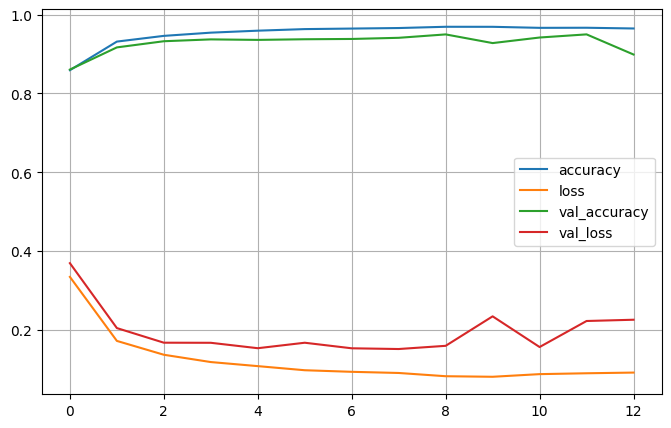

```python
pd.DataFrame(history.history).plot(figsize=(8, 5))
plt.grid(True)
plt.show()
```

# A little evalutaion of it with the test data

```python
model.evaluate(test)
```

```
341/341 ━━━━━━━━━━━━━━━━━━━━ 18s 51ms/step - accuracy: 0.9232 - loss: 0.1892
```

```
[0.1964750587940216, 0.9223291873931885]
```

```python
model.save("modelo_detector_caras.keras")
```

# And with this Confussion Matrix we are going to Plot the results with the Test Data

[output not shown]

[output not shown]

[output not shown]

[output cut: 283 more lines]

[output not shown]

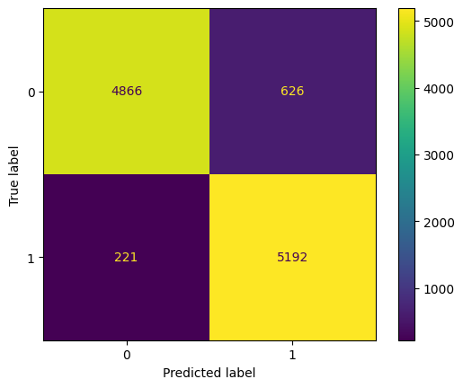

```python
from sklearn.metrics import confusion_matrix, ConfusionMatrixDisplay


true_labels = []
predictions = []

for images, labels in test:
    true_labels.extend(labels.numpy())
    batch_predictions = model.predict(images) >= 0.5
    predictions.extend(batch_predictions.astype(int).flatten())

true_labels = np.array(true_labels)
predictions = np.array(predictions)

cm = confusion_matrix(true_labels, predictions)
disp = ConfusionMatrixDisplay(confusion_matrix=cm)
disp.plot()
plt.show()
```